# Classification_Project_Bank_Dataset_Hemlata

### Project 2: Supervised Learning - Classification

### Data Description:

The file Bank.xls contains data on 5000 customers. The data include customer demographic information (age, income, etc.), the customer's relationship with the bank (mortgage, securities account, etc.), and the customer response to the last personal loan campaign (Personal Loan). Among these 5000 customers, only 480 (= 9.6%) accepted the personal loan that was offered to them in the earlier campaign.

### Domain: Banking

### Context:

This case is about a bank (Thera Bank) whose management wants to explore ways of converting its liability customers to personal loan customers (while retaining them as depositors). A campaign that the bank ran last year for liability customers showed a healthy conversion rate of over 9% success. This has encouraged the retail marketing department to devise campaigns with better target marketing to increase the success ratio with minimal budget.

```python
import numpy as np # linear algebra
import pandas as pd # data processing, CSV file I/O (e.g. pd.read_csv)
import matplotlib.pyplot as plt       # matplotlib.pyplot plots data
%matplotlib inline

import seaborn as sns
from sklearn.model_selection import train_test_split
from sklearn.impute import SimpleImputer
from sklearn.naive_bayes import GaussianNB
from sklearn.neighbors import KNeighborsClassifier
from scipy.stats import zscore
from sklearn import metrics

from sklearn.linear_model import LogisticRegression
```

## Task 1: Read the column description and ensure you understand each attribute well

```python
Data = pd.read_csv("Bank_Personal_Loan_Modelling.csv")
Data.head()
```

|  | ID | Age | Experience | Income | ZIP Code | Family | CCAvg | Education | Mortgage | Personal Loan | Securities Account | CD Account | Online | CreditCard |
| --- | --- | --- | --- | --- | --- | --- | --- | --- | --- | --- | --- | --- | --- | --- |
| 0 | 1 | 25 | 1 | 49 | 91107 | 4 | 1.6 | 1 | 0 | 0 | 1 | 0 | 0 | 0 |
| 1 | 2 | 45 | 19 | 34 | 90089 | 3 | 1.5 | 1 | 0 | 0 | 1 | 0 | 0 | 0 |
| 2 | 3 | 39 | 15 | 11 | 94720 | 1 | 1.0 | 1 | 0 | 0 | 0 | 0 | 0 | 0 |
| 3 | 4 | 35 | 9 | 100 | 94112 | 1 | 2.7 | 2 | 0 | 0 | 0 | 0 | 0 | 0 |
| 4 | 5 | 35 | 8 | 45 | 91330 | 4 | 1.0 | 2 | 0 | 0 | 0 | 0 | 0 | 1 |

```python
Data.columns
```

```
Index(['ID', 'Age', 'Experience', 'Income', 'ZIP Code', 'Family', 'CCAvg',
       'Education', 'Mortgage', 'Personal Loan', 'Securities Account',
       'CD Account', 'Online', 'CreditCard'],
      dtype='object')
```

```python
Data.info()
```

```
<class 'pandas.core.frame.DataFrame'>
RangeIndex: 5000 entries, 0 to 4999
Data columns (total 14 columns):
 #   Column              Non-Null Count  Dtype
---  ------              --------------  -----
 0   ID                  5000 non-null   int64
 1   Age                 5000 non-null   int64
 2   Experience          5000 non-null   int64
 3   Income              5000 non-null   int64
 4   ZIP Code            5000 non-null   int64
 5   Family              5000 non-null   int64
 6   CCAvg               5000 non-null   float64
 7   Education           5000 non-null   int64
 8   Mortgage            5000 non-null   int64
 9   Personal Loan       5000 non-null   int64
 10  Securities Account  5000 non-null   int64
 11  CD Account          5000 non-null   int64
 12  Online              5000 non-null   int64
 13  CreditCard          5000 non-null   int64
dtypes: float64(1), int64(13)
memory usage: 547.0 KB
```

```python
Data.describe().transpose
```

```
<bound method DataFrame.transpose of                 ID          Age   Experience       Income      ZIP Code  \
count  5000.000000  5000.000000  5000.000000  5000.000000   5000.000000
mean   2500.500000    45.338400    20.104600    73.774200  93152.503000
std    1443.520003    11.463166    11.467954    46.033729   2121.852197
min       1.000000    23.000000    -3.000000     8.000000   9307.000000
25%    1250.750000    35.000000    10.000000    39.000000  91911.000000
50%    2500.500000    45.000000    20.000000    64.000000  93437.000000
75%    3750.250000    55.000000    30.000000    98.000000  94608.000000
max    5000.000000    67.000000    43.000000   224.000000  96651.000000

            Family        CCAvg    Education     Mortgage  Personal Loan  \
count  5000.000000  5000.000000  5000.000000  5000.000000    5000.000000
mean      2.396400     1.937938     1.881000    56.498800       0.096000
std       1.147663     1.747659     0.839869   101.713802       0.294621
min       1.000000     0.000000     1.000000     0.000000       0.000000
25%       1.000000     0.700000     1.000000     0.000000       0.000000
50%       2.000000     1.500000     2.000000     0.000000       0.000000
75%       3.000000     2.500000     3.000000   101.000000       0.000000
max       4.000000    10.000000     3.000000   635.000000       1.000000

       Securities Account  CD Account       Online   CreditCard
count         5000.000000  5000.00000  5000.000000  5000.000000
mean             0.104400     0.06040     0.596800     0.294000
std              0.305809     0.23825     0.490589     0.455637
min              0.000000     0.00000     0.000000     0.000000
25%              0.000000     0.00000     0.000000     0.000000
50%              0.000000     0.00000     1.000000     0.000000
75%              0.000000     0.00000     1.000000     1.000000
max              1.000000     1.00000     1.000000     1.000000  >
```

## Findings from column description

1. All the columns are numeric and the dataset does not have any null values.
2. 'Family','Education' columns has categorical values
3. 'Personal Loan','Securities Account', 'CD Account','Online','CreditCard' has binary values.

## Task2: Study the data distribution in each attribute, share your findings (15)

## For Data distribution in each attribute.

### Boxplot shows outliers in 'Income' , 'CCAvg' and 'Mortgage' attributes.

### Plotted countplots of categorical columns 'Family', 'Education', 'CD Account', 'Online', 'Securities Account', 'Credit Card','Personal Loan'.

### The features 'CD Account', 'Online', 'Securities Account', 'Credit Card','Personal Loan' are categorical and takes binary values.

### Average spending 'CCAvg' i.e. Avg. spending on credit cards per month distribution shows it is right skewed.

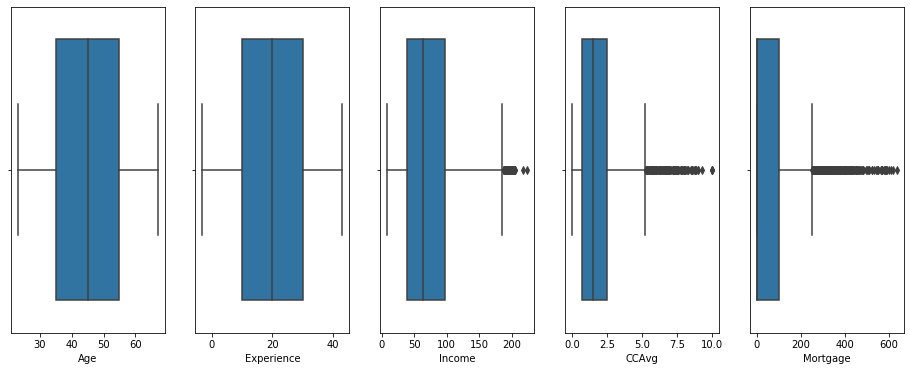

```python
fig, ax =plt.subplots(1,5, figsize = (16,6))
sns.boxplot(Data['Age'], ax=ax[0])
sns.boxplot(Data['Experience'], ax =ax[1])
sns.boxplot(Data['Income'], ax = ax[2])
sns.boxplot(Data['CCAvg'], ax = ax[3])
sns.boxplot(Data['Mortgage'], ax = ax[4])
plt.show()
```

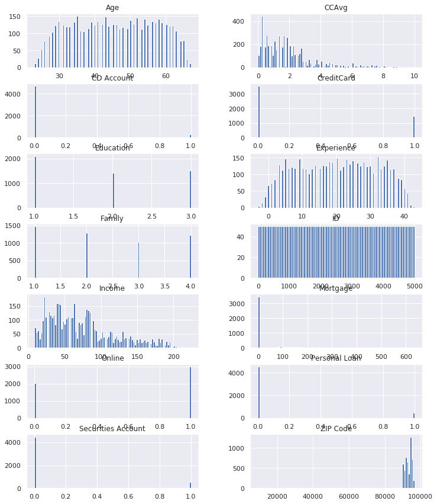

```python
Data.hist(stacked=False, bins=100, figsize=(12,30), layout=(14,2));
```

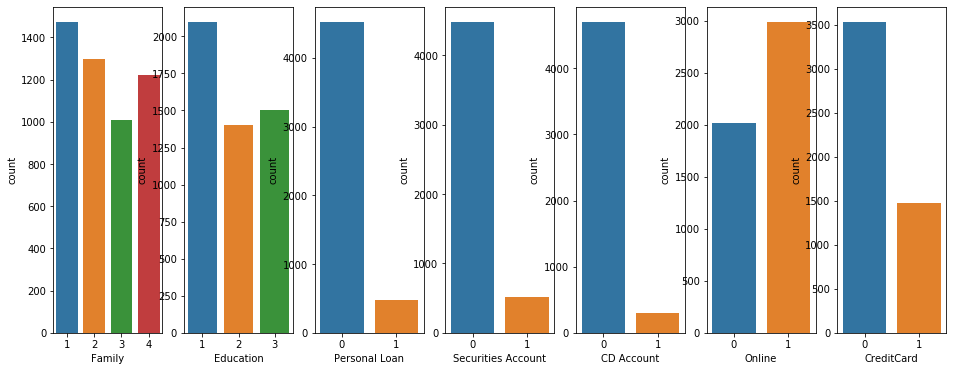

```python
fig, ax =plt.subplots(1,7, figsize = (16,6))
sns.countplot(Data['Family'], ax=ax[0])
sns.countplot(Data['Education'], ax =ax[1])
sns.countplot(Data['Personal Loan'], ax = ax[2])
sns.countplot(Data['Securities Account'], ax = ax[3])
sns.countplot(Data['CD Account'], ax = ax[4])
sns.countplot(Data['Online'], ax = ax[5])
sns.countplot(Data['CreditCard'], ax = ax[6])
plt.show()
```

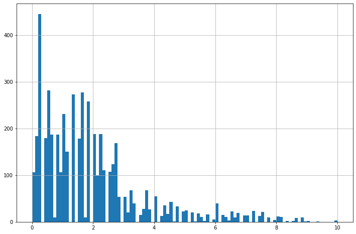

```python
Data['CCAvg'].hist(stacked=False, bins=100, figsize=(12,8));
```

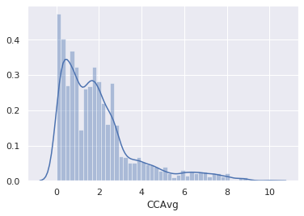

```python
sns.set()    #setting seaborn style to default
sns.distplot(Data.CCAvg)
plt.show()
```

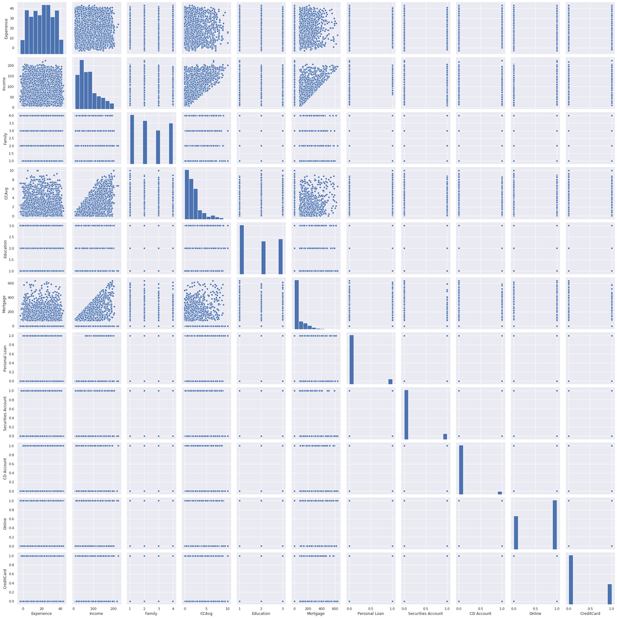

```python
sns.pairplot(Data[['Experience', 'Income','Family', 'CCAvg',
       'Education', 'Mortgage', 'Personal Loan', 'Securities Account',
       'CD Account', 'Online', 'CreditCard']])
```

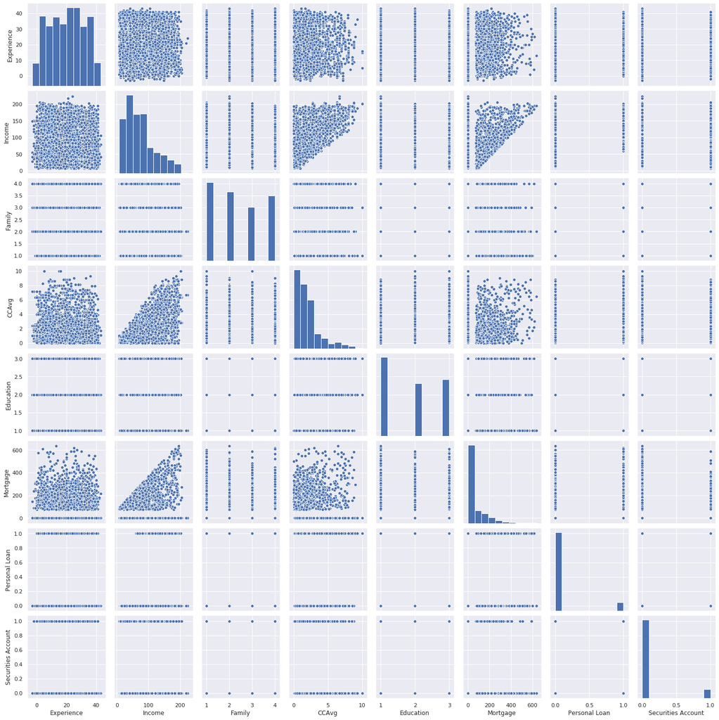

```python
sns.pairplot(Data[['Experience', 'Income','Family', 'CCAvg',
       'Education', 'Mortgage', 'Personal Loan', 'Securities Account']])
```

### Task3: Get the target column distribution. Your comments (5)

Plotted the bar plot. The plot shows the counts of customers who accepts the Personal loan in last campaign around 480 out of 5000 records in the dataset which is approximately 9.6% of customers. This shows siggnificant outcome from the campaign.

```python
Data['Personal Loan'].value_counts()
```

```
0    4520
1     480
Name: Personal Loan, dtype: int64
```

```python
Data['Personal Loan'].value_counts()/Data.shape[0]*100
```

```
0    90.4
1     9.6
Name: Personal Loan, dtype: float64
```

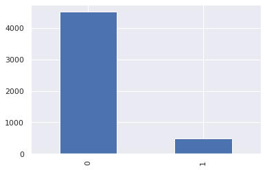

```python
Data['Personal Loan'].value_counts().plot(kind='bar');
```

### Task4: Split the data into training and test set in the ratio of 70:30 respectively (5)

```python
x = Data.drop('Personal Loan',axis=1)
y = Data['Personal Loan']
x_train, x_test, y_train, y_test = train_test_split(x, y, test_size=0.3, random_state=42)
```

```python
Data.shape,x_train.shape,x_test.shape
```

```
((5000, 14), (3500, 13), (1500, 13))
```

### Task5: Use different classification models (Logistic, K-NN and Naïve Bayes) to predict the likelihood of a customer buying personal loans (15)

### 1. Logistic Regression

```python
# Fit the model on train
lr_model = LogisticRegression(solver="liblinear")
lr_model.fit(x_train, y_train)
#predict on test
y_predict = lr_model.predict(x_test)


coef_df = pd.DataFrame(lr_model.coef_)
coef_df['intercept'] = lr_model.intercept_
print(coef_df)
model_score = lr_model.score(x_test, y_test)
print("Train Accuracy with Logistic Regression = ",lr_model.score(x_train, y_train) )
print("Test Accuracy with Logistic Regression = ",model_score)
```

```
          0         1         2         3         4         5         6  \
0 -0.000086  0.000785  0.000757  0.035618 -0.000063  0.000693  0.001193

          7         8        9        10        11        12  intercept
0  0.000819  0.000955  0.00003  0.000284  0.000018 -0.000007  -0.000004
Train Accuracy with Logistic Regression =  0.9117142857142857
Test Accuracy with Logistic Regression =  0.9006666666666666
```

### 2. K-NN Model

```python
NNH = KNeighborsClassifier(n_neighbors= 7 , weights = 'distance' )
NNH.fit(x_train,y_train)
predicted_labels = NNH.predict(x_test)
print("Train Accuracy with KNN = ",NNH.score(x_train, y_train) )
print("Test Accuracy with KNN = ",NNH.score(x_test, y_test))
```

```
Train Accuracy with KNN =  1.0
Test Accuracy with KNN =  0.8926666666666667
```

### 3. Naive Bayes Model

```python
model_NB = GaussianNB()
model_NB.fit(x_train, y_train)
#predict on test
y_predict_NB = model_NB.predict(x_test)
model_score_NB = model_NB.score(x_test, y_test)
print("Train Accuracy with Naive Bayes = ",model_NB.score(x_train, y_train) )
print("Test Accuracy with Naive Bayes = ",model_score_NB)
```

```
Train Accuracy with Naive Bayes =  0.8891428571428571
Test Accuracy with Naive Bayes =  0.896
```

```python
print("Train Accuracy with Logistic Regression = ",lr_model.score(x_train, y_train) )
print("Test Accuracy with Logistic Regression = ",model_score)
print("Train Accuracy with KNN = ",NNH.score(x_train, y_train) )
print("Test Accuracy with KNN = ",NNH.score(x_test, y_test))
print("Train Accuracy with Naive Bayes = ",model_NB.score(x_train, y_train) )
print("Test Accuracy with Naive Bayes = ",model_score_NB)
```

```
Train Accuracy with Logistic Regression =  0.9117142857142857
Test Accuracy with Logistic Regression =  0.9006666666666666
Train Accuracy with KNN =  1.0
Test Accuracy with KNN =  0.8926666666666667
Train Accuracy with Naive Bayes =  0.8891428571428571
Test Accuracy with Naive Bayes =  0.896
```

### Task6: Print the confusion matrix for all the above models (5 marks)

### 1. Confusion Matrix of logistic regression model

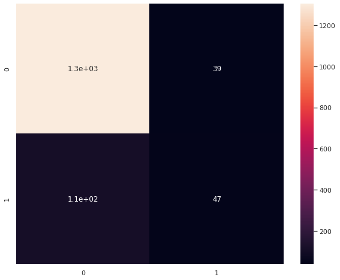

```python
cm=metrics.confusion_matrix(y_test, y_predict , labels=[0,1])

df_cm = pd.DataFrame(cm, index = [0,1],columns = [0,1])
plt.figure(figsize = (10,8))
sns.heatmap(df_cm, annot=True);
```

### 2. Confusion matrix for K-NN model

```
Confusion Matrix
```

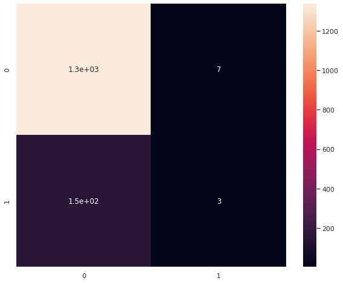

```python
# calculate accuracy measures and confusion matrix
from sklearn import metrics

print("Confusion Matrix")
cm1=metrics.confusion_matrix(y_test, predicted_labels, labels=[0,1])

df_cm1 = pd.DataFrame(cm1, index = [i for i in [0,1]],
                  columns = [i for i in [0,1]])
plt.figure(figsize = (10,8))
sns.heatmap(df_cm1, annot=True)
```

### 3. Naive Bayes model Confusion matrix

```
Confusion Matrix
```

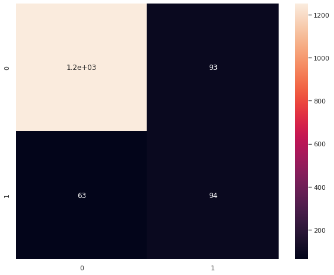

```python
# calculate accuracy measures and confusion matrix
from sklearn import metrics

print("Confusion Matrix")
cm2=metrics.confusion_matrix(y_test, y_predict_NB, labels=[0,1])

df_cm2 = pd.DataFrame(cm2, index = [i for i in [0,1]],
                  columns = [i for i in [0,1]])
plt.figure(figsize = (10,8))
sns.heatmap(df_cm2, annot=True)
```

### Task7: Give your reasoning on which is the best model in this case and why it performs better? (5 marks)

```python
from sklearn.metrics import classification_report
#classification report for Logistic regression
print(classification_report(y_test, y_predict))
```

```
              precision    recall  f1-score   support

           0       0.92      0.97      0.95      1343
           1       0.55      0.30      0.39       157

    accuracy                           0.90      1500
   macro avg       0.73      0.64      0.67      1500
weighted avg       0.88      0.90      0.89      1500
```

```python
#classification report for Naive Bayes
print(classification_report(y_test, y_predict_NB))
```

```
              precision    recall  f1-score   support

           0       0.95      0.93      0.94      1343
           1       0.50      0.60      0.55       157

    accuracy                           0.90      1500
   macro avg       0.73      0.76      0.74      1500
weighted avg       0.90      0.90      0.90      1500
```

```python
#classification report for KNN
print(classification_report(y_test, predicted_labels))
```

```
              precision    recall  f1-score   support

           0       0.90      0.99      0.94      1343
           1       0.30      0.02      0.04       157

    accuracy                           0.89      1500
   macro avg       0.60      0.51      0.49      1500
weighted avg       0.83      0.89      0.85      1500
```